# Self-Driving Car Engineer Nanodegree

## Project: Build a Traffic Sign Recognition Classifier

In this notebook, a template is provided for you to implement your functionality in stages, which is required to successfully complete this project. If additional code is required that cannot be included in the notebook, be sure that the Python code is successfully imported and included in your submission if necessary.

In addition to implementing code, there is a writeup to complete. The writeup should be completed in a separate file, which can be either a markdown file or a pdf document. There is a [write up template](https://github.com/udacity/CarND-Traffic-Sign-Classifier-Project/blob/master/writeup_template.md) that can be used to guide the writing process. Completing the code template and writeup template will cover all of the [rubric points](https://review.udacity.com/#!/rubrics/481/view) for this project.

The [rubric](https://review.udacity.com/#!/rubrics/481/view) contains "Stand Out Suggestions" for enhancing the project beyond the minimum requirements. The stand out suggestions are optional. If you decide to pursue the "stand out suggestions", you can include the code in this Ipython notebook and also discuss the results in the writeup file.

> **Note:** Code and Markdown cells can be executed using the **Shift + Enter** keyboard shortcut. In addition, Markdown cells can be edited by typically double-clicking the cell to enter edit mode.

## Step 0: Load The Data

```python
# Imports
import os
import cv2
import pickle
import random
import warnings
import numpy as np
from matplotlib import pyplot
from skimage import exposure
from numpy import newaxis
from scipy import ndimage
import tensorflow as tf
from tensorflow.contrib.layers import flatten
from sklearn.utils import shuffle
from pandas.io.parsers import read_csv
from skimage import io
import matplotlib.gridspec as gridspec
```

```python
# Load pickled data
training_file = 'traffic-signs-data/train.p'
validation_file = 'traffic-signs-data/valid.p'
testing_file = 'traffic-signs-data/test.p'

with open(training_file, mode='rb') as f:
    train = pickle.load(f)
with open(validation_file, mode='rb') as f:
    valid = pickle.load(f)
with open(testing_file, mode='rb') as f:
    test = pickle.load(f)

X_train, y_train = train['features'], train['labels']
X_valid, y_valid = valid['features'], valid['labels']
X_test, y_test = test['features'], test['labels']

signnames = read_csv("signnames.csv").values[:, 1]
```

## Step 1: Dataset Summary & Exploration

The pickled data is a dictionary with 4 key/value pairs:

- `'features'` is a 4D array containing raw pixel data of the traffic sign images, (num examples, width, height, channels).
- `'labels'` is a 1D array containing the label/class id of the traffic sign. The file `signnames.csv` contains id -> name mappings for each id.
- `'sizes'` is a list containing tuples, (width, height) representing the original width and height the image.
- `'coords'` is a list containing tuples, (x1, y1, x2, y2) representing coordinates of a bounding box around the sign in the image. **THESE COORDINATES ASSUME THE ORIGINAL IMAGE. THE PICKLED DATA CONTAINS RESIZED VERSIONS (32 by 32) OF THESE IMAGES**

Complete the basic data summary below. Use python, numpy and/or pandas methods to calculate the data summary rather than hard coding the results. For example, the [pandas shape method](http://pandas.pydata.org/pandas-docs/stable/generated/pandas.DataFrame.shape.html) might be useful for calculating some of the summary results.

### Provide a Basic Summary of the Data Set Using Python, Numpy and/or Pandas

```python
# Basic Summary

# Number of training examples
n_train = np.shape(train['features'])[0]

# Number of validation examples.
n_valid = np.shape(valid['features'])[0]

# Number of testing examples.
n_test = np.shape(test['features'])[0]

# The shape of an traffic sign image
image_shape = (np.shape(test['features'])[1], np.shape(test['features'])[2])

# How many unique classes/labels there are in the dataset.
n_classes = np.shape(np.unique(train['labels']))[0]

print("Number of training examples =", n_train)
print("Number of validation examples =", n_valid)
print("Number of testing examples =", n_test)
print("Image data shape =", image_shape)
print("Number of classes =", n_classes)
```

```
Number of training examples = 34799
Number of validation examples = 4410
Number of testing examples = 12630
Image data shape = (32, 32)
Number of classes = 43
```

### Include an exploratory visualization of the dataset

Visualize the German Traffic Signs Dataset using the pickled file(s). This is open ended, suggestions include: plotting traffic sign images, plotting the count of each sign, etc.

The [Matplotlib](http://matplotlib.org/) [examples](http://matplotlib.org/examples/index.html) and [gallery](http://matplotlib.org/gallery.html) pages are a great resource for doing visualizations in Python.

**NOTE:** It's recommended you start with something simple first. If you wish to do more, come back to it after you've completed the rest of the sections.

```
Class 0: Speed limit (20km/h)                                180 samples
```

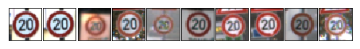

```
----------------------------------------------------------------------------

Class 1: Speed limit (30km/h)                                1980 samples
```

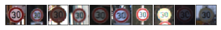

```
----------------------------------------------------------------------------

Class 2: Speed limit (50km/h)                                2010 samples
```

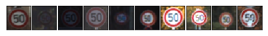

```
----------------------------------------------------------------------------

Class 3: Speed limit (60km/h)                                1260 samples
```

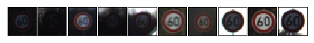

```
----------------------------------------------------------------------------

Class 4: Speed limit (70km/h)                                1770 samples
```

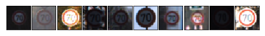

```
----------------------------------------------------------------------------

Class 5: Speed limit (80km/h)                                1650 samples
```

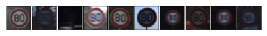

```
----------------------------------------------------------------------------

Class 6: End of speed limit (80km/h)                         360 samples
```

[figure not shown]

```
----------------------------------------------------------------------------

Class 7: Speed limit (100km/h)                               1290 samples
```

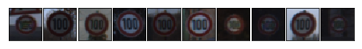

```
----------------------------------------------------------------------------

Class 8: Speed limit (120km/h)                               1260 samples
```

[figure not shown]

```
----------------------------------------------------------------------------

Class 9: No passing                                          1320 samples
```

[figure not shown]

```
----------------------------------------------------------------------------

Class 10: No passing for vehicles over 3.5 metric tons        1800 samples
```

[figure not shown]

```
----------------------------------------------------------------------------

Class 11: Right-of-way at the next intersection               1170 samples
```

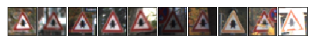

```
----------------------------------------------------------------------------

Class 12: Priority road                                       1890 samples
```

[32 more figures not shown]

```python
# Visualizations will be shown in the notebook.
%matplotlib inline

sign_classes, class_indices, class_counts = \
    np.unique(y_train, return_index = True, return_counts = True)

col_width = max(len(name) for name in signnames)

def visualize_dataset():
    for c, c_index, c_count in zip(sign_classes, class_indices, class_counts):
        print("Class %i: %-*s  %s samples" % (c, col_width, signnames[c], str(c_count)))
        fig = pyplot.figure(figsize=(6, 1))
        fig.subplots_adjust(left=0, right=1, bottom=0, top=1, hspace=0.05, wspace=0.05)
        random_indices = random.sample(range(c_index, c_index + c_count), 10)
        for i in range(10):
            axis = fig.add_subplot(1, 10, i + 1, xticks=[], yticks=[])
            axis.imshow(X_train[random_indices[i]])
        pyplot.show()
        print("----------------------------------------------------------------------------\n")

visualize_dataset()

pyplot.bar(np.arange(43), class_counts, align='center')
pyplot.xlabel('Class')
pyplot.ylabel('Number of training examples')
pyplot.xlim([-1, 43])
pyplot.show()
```

## Step 2: Design and Test a Model Architecture

Design and implement a deep learning model that learns to recognize traffic signs. Train and test your model on the [German Traffic Sign Dataset](http://benchmark.ini.rub.de/?section=gtsrb&subsection=dataset).

The LeNet-5 implementation shown in the classroom at the end of the CNN lesson is a solid starting point. You'll have to change the number of classes and possibly the preprocessing, but aside from that it's plug and play!

With the LeNet-5 solution from the lecture, you should expect a validation set accuracy of about 0.89. To meet specifications, the validation set accuracy will need to be at least 0.93. It is possible to get an even higher accuracy, but 0.93 is the minimum for a successful project submission.

There are various aspects to consider when thinking about this problem:

- Neural network architecture (is the network over or underfitting?)
- Play around preprocessing techniques (normalization, rgb to grayscale, etc)
- Number of examples per label (some have more than others).
- Generate fake data.

Here is an example of a [published baseline model on this problem](http://yann.lecun.com/exdb/publis/pdf/sermanet-ijcnn-11.pdf). It's not required to be familiar with the approach used in the paper but, it's good practice to try to read papers like these.

### Pre-process the Data Set (normalization, grayscale, etc.)

Use the code cell (or multiple code cells, if necessary) to implement the first step of your project.

```python
def preprocess(X):
    #Convert to grayscale, e.g. single channel Y
    X = 0.299 * X[:, :, :, 0] + 0.587 * X[:, :, :, 1] + 0.114 * X[:, :, :, 2]
    #Scale features to be in [0, 1]
    X = (X / 255.).astype(np.float32)

    for i in range(X.shape[0]):
        with warnings.catch_warnings():
            warnings.simplefilter("ignore")
            X[i] = exposure.equalize_adapthist(X[i])

    # Add a single grayscale channel
    X = X.reshape(X.shape + (1,))
    return X
```

```python
print('Preprocessing training data...')
X_train = preprocess(X_train)
print('Finished preprocessing training data.')
# Double-check that the image is changed to depth of 1
image_shape2 = X_train.shape
print("Processed training data shape =", image_shape2)

print('Preprocessing validation data...')
X_valid = preprocess(X_valid)
print('Finished validation testing data.')
# Double-check that the image is changed to depth of 1
image_shape4 = X_valid.shape
print("Processed validation data shape =", image_shape4)

print('Preprocessing testing data...')
X_test = preprocess(X_test)
print('Finished preprocessing testing data.')
# Double-check that the image is changed to depth of 1
image_shape3 = X_test.shape
print("Processed testing data shape =", image_shape3)

print('All data preprocessing complete.')
```

```
Preprocessing training data...
Finished preprocessing training data.
Processed training data shape = (34799, 32, 32, 1)
Preprocessing validation data...
Finished validation testing data.
Processed validation data shape = (4410, 32, 32, 1)
Preprocessing testing data...
Finished preprocessing testing data.
Processed testing data shape = (12630, 32, 32, 1)
All data preprocessing complete.
```

```python
# Generate additional data
def generate_new_data(x_set, y_set):
    # min_desired below is just mean_pics but wanted to make the code below easier to distinguish
    pics_in_class = np.bincount(y_set)
    mean_pics = int(np.mean(pics_in_class))
    min_desired = int(mean_pics)

    print('Generating new data.')

    # Angles to be used to rotate images in additional data made
    angles = [-5, 5, -10, 10, -15, 15, -20, 20, -25, 25]

    # Iterate through each class
    for i in range(len(pics_in_class)):

        # Check if less data than the mean
        if pics_in_class[i] < min_desired:

            # Count how many additional pictures we want
            new_wanted = min_desired - pics_in_class[i]
            picture = np.where(y_set == i)
            more_X = []
            more_y = []

            # Make the number of additional pictures needed to arrive at the mean
            for num in range(new_wanted):
                # Rotate images and append new ones to more_X, append the class to more_y
                more_X.append(
                    ndimage.rotate(x_set[picture][random.randint(0, pics_in_class[i] - 1)], random.choice(angles),
                                   reshape=False))
                more_y.append(i)

            # Append the pictures generated for each class back to the original data
            x_set = np.append(x_set, np.array(more_X), axis=0)
            y_set = np.append(y_set, np.array(more_y), axis=0)

    return x_set, y_set, min_desired
```

```
Generating new data.
Additional data generated. Any classes lacking data now have 809 pictures.
The updated number of training examples = 46714
Generating new data.
Additional data generated. Any classes lacking data now have 102 pictures.
The updated number of validation examples = 5682
```

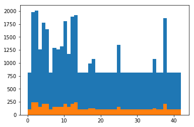

```python
X_train, y_train, min_train_desired = generate_new_data(X_train, y_train)
print('Additional data generated. Any classes lacking data now have', min_train_desired, 'pictures.')
pyplot.hist(y_train, bins = n_classes)
updated_n_train = len(X_train)
print("The updated number of training examples =", updated_n_train)

X_valid, y_valid, min_valid_desired = generate_new_data(X_valid, y_valid)
print('Additional data generated. Any classes lacking data now have', min_valid_desired, 'pictures.')
pyplot.hist(y_valid, bins = n_classes)
updated_n_valid = len(X_valid)
print("The updated number of validation examples =", updated_n_valid)
```

```python
def flip_extend(X, y):
    # Classes of signs that, when flipped horizontally, should still be classified as the same class
    self_flippable_horizontally = np.array([11, 12, 13, 15, 17, 18, 22, 26, 30, 35])
    # Classes of signs that, when flipped vertically, should still be classified as the same class
    self_flippable_vertically = np.array([1, 5, 12, 15, 17])
    # Classes of signs that, when flipped horizontally and then vertically, should still be classified as the same class
    self_flippable_both = np.array([32, 40])
    # Classes of signs that, when flipped horizontally, would still be meaningful, but should be classified as some other class
    cross_flippable = np.array([
        [19, 20],
        [33, 34],
        [36, 37],
        [38, 39],
        [20, 19],
        [34, 33],
        [37, 36],
        [39, 38],
    ])
    num_classes = 43

    X_extended = np.empty([0, X.shape[1], X.shape[2], X.shape[3]], dtype=X.dtype)
    y_extended = np.empty([0], dtype=y.dtype)

    for c in range(num_classes):
        # First copy existing data for this class
        X_extended = np.append(X_extended, X[y == c], axis=0)
        # If we can flip images of this class horizontally and they would still belong to said class...
        if c in self_flippable_horizontally:
            # ...Copy their flipped versions into extended array.
            X_extended = np.append(X_extended, X[y == c][:, :, ::-1, :], axis=0)
        # If we can flip images of this class horizontally and they would belong to other class...
        if c in cross_flippable[:, 0]:
            # ...Copy flipped images of that other class to the extended array.
            flip_class = cross_flippable[cross_flippable[:, 0] == c][0][1]
            X_extended = np.append(X_extended, X[y == flip_class][:, :, ::-1, :], axis=0)
        # Fill labels for added images set to current class.
        y_extended = np.append(y_extended, np.full((X_extended.shape[0] - y_extended.shape[0]), c, dtype=int))

        # If we can flip images of this class vertically and they would still belong to said class...
        if c in self_flippable_vertically:
            # ...Copy their flipped versions into extended array.
            X_extended = np.append(X_extended, X_extended[y_extended == c][:, ::-1, :, :], axis=0)
        # Fill labels for added images set to current class.
        y_extended = np.append(y_extended, np.full((X_extended.shape[0] - y_extended.shape[0]), c, dtype=int))

        # If we can flip images of this class horizontally AND vertically and they would still belong to said class...
        if c in self_flippable_both:
            # ...Copy their flipped versions into extended array.
            X_extended = np.append(X_extended, X_extended[y_extended == c][:, ::-1, ::-1, :], axis=0)
        # Fill labels for added images set to current class.
        y_extended = np.append(y_extended, np.full((X_extended.shape[0] - y_extended.shape[0]), c, dtype=int))

    return (X_extended, y_extended)
```

```python
X_train, y_train = flip_extend(X_train, y_train)
X_valid, y_valid = flip_extend(X_valid, y_valid)

print("Number of training examples after horizontal flipping =", X_train.shape[0])
print("Number of validation examples after horizontal flipping =", X_valid.shape[0])
```

```
Number of training examples after horizontal flipping = 78229
Number of validation examples after horizontal flipping = 9492
```

### Model Architecture

```python
### Define your architecture here.
# Set placeholder variables for x, y, and the keep_prob for dropout
# Also, one-hot encode y
x = tf.placeholder(tf.float32, (None, 32, 32, 1))
y = tf.placeholder(tf.int32, (None))
keep_prob = tf.placeholder(tf.float32)
one_hot_y = tf.one_hot(y, 43)

EPOCHS = 120
BATCH_SIZE = 150
```

```python
### Model definition
def model(x):
    # Hyperparameters
    mu = 0
    sigma = 0.1

    # Layer 1: Convolutional. Input = 32x32x1. Output = 28x28x6.
    conv1_W = tf.Variable(tf.truncated_normal(shape=(5, 5, 1, 6), mean=mu, stddev=sigma))
    conv1_b = tf.Variable(tf.zeros(6))
    conv1 = tf.nn.conv2d(x, conv1_W, strides=[1, 1, 1, 1], padding='VALID') + conv1_b

    # Activation for layer 1
    conv1 = tf.nn.relu(conv1)

    # Pooling. Input = 28x28x6. Output = 14x14x6.
    conv1 = tf.nn.avg_pool(conv1, ksize=[1, 2, 2, 1], strides=[1, 2, 2, 1], padding='VALID')

    # Layer 2: Convolutional. Output = 10x10x16.
    conv2_W = tf.Variable(tf.truncated_normal(shape=(5, 5, 6, 16), mean=mu, stddev=sigma))
    conv2_b = tf.Variable(tf.zeros(16))
    conv2 = tf.nn.conv2d(conv1, conv2_W, strides=[1, 1, 1, 1], padding='VALID') + conv2_b

    # Activation for layer 2
    conv2 = tf.nn.relu(conv2)

    # Pooling. Input = 10x10x16. Output = 5x5x16.
    conv2 = tf.nn.avg_pool(conv2, ksize=[1, 2, 2, 1], strides=[1, 2, 2, 1], padding='VALID')

    # Flatten to get to fully connected layers. Input = 5x5x16. Output = 400.
    flattened = tf.contrib.layers.flatten(conv2)

    # Layer 3: Fully Connected. Input = 400. Output = 200.
    fc1_W = tf.Variable(tf.truncated_normal(shape=(400, 200), mean=mu, stddev=sigma))
    fc1_b = tf.Variable(tf.zeros(200))
    fc1 = tf.matmul(flattened, fc1_W) + fc1_b

    # Activation for the first fully connected layer.
    fc1 = tf.nn.relu(fc1)

    # Dropout, to prevent overfitting
    fc1 = tf.nn.dropout(fc1, keep_prob)

    # Layer 4: Fully Connected. Input = 200. Output = 100.
    fc2_W = tf.Variable(tf.truncated_normal(shape=(200, 100), mean=mu, stddev=sigma))
    fc2_b = tf.Variable(tf.zeros(100))
    fc2 = tf.matmul(fc1, fc2_W) + fc2_b

    # Activation.
    fc2 = tf.nn.relu(fc2)

    # Dropout
    fc2 = tf.nn.dropout(fc2, keep_prob)

    # Layer 5 Fully Connected. Input = 100. Output = 43.
    fc3_W = tf.Variable(tf.truncated_normal(shape=(100, 43), mean=mu, stddev=sigma))
    fc3_b = tf.Variable(tf.zeros(43))
    logits = tf.matmul(fc2, fc3_W) + fc3_b

    return logits, conv1, conv2, fc1, fc2
```

### Train, Validate and Test the Model

A validation set can be used to assess how well the model is performing. A low accuracy on the training and validation sets imply underfitting. A high accuracy on the training set but low accuracy on the validation set implies overfitting.

```python
### Train your model here.
### Calculate and report the accuracy on the training and validation set.
### Once a final model architecture is selected,
### the accuracy on the test set should be calculated and reported as well.
# Setting learning rate, loss functions, and optimizer
rate = 0.001

logits, conv_layer1, conv_layer2, fc1, fc2 = model(x)
# logits, conv1, conv2, conv3, fc1 = model(x)
cross_entropy = tf.nn.softmax_cross_entropy_with_logits(logits=logits, labels=one_hot_y)
loss_operation = tf.reduce_mean(cross_entropy)
optimizer = tf.train.AdamOptimizer(learning_rate = rate)
training_operation = optimizer.minimize(loss_operation)

# The below is used in the validation part of the model of the neural network
correct_prediction = tf.equal(tf.argmax(logits, 1), tf.argmax(one_hot_y, 1))
accuracy_operation = tf.reduce_mean(tf.cast(correct_prediction, tf.float32))

def evaluate(X_data, y_data):
    num_examples = len(X_data)
    total_accuracy = 0
    sess = tf.get_default_session()
    for offset in range(0, num_examples, BATCH_SIZE):
        batch_x, batch_y = X_data[offset:offset+BATCH_SIZE], y_data[offset:offset+BATCH_SIZE]
        accuracy =  sess.run(accuracy_operation, feed_dict={x: batch_x, y: batch_y, keep_prob : 1.0})
        total_accuracy += (accuracy * len(batch_x))
    return total_accuracy / num_examples


### Train your model here.
### Feel free to use as many code cells as needed.
save_file = 'train_model'
saver = tf.train.Saver()

with tf.Session() as sess:
    sess.run(tf.global_variables_initializer())
    num_examples = len(X_train)

    print("Training...")
    print()
    for i in range(EPOCHS):
        X_train, y_train = shuffle(X_train, y_train)
        for offset in range(0, num_examples, BATCH_SIZE):
            end = offset + BATCH_SIZE
            batch_x, batch_y = X_train[offset:end], y_train[offset:end]
            loss = sess.run(training_operation, feed_dict={x: batch_x, y: batch_y, keep_prob: 0.7})

        train_accuracy = evaluate(X_train, y_train)
        validation_accuracy = evaluate(X_valid, y_valid)
        print("EPOCH {} ...".format(i + 1))
        print("Train Accuracy = {:.3f}".format(train_accuracy))
        print("Validation Accuracy = {:.3f}".format(validation_accuracy))
        print()

    # Save the model
    saver.save(sess, './' + save_file)
    print('Trained Model Saved.')
```

```
Training...

EPOCH 1 ...
Train Accuracy = 0.838
Validation Accuracy = 0.805

EPOCH 2 ...
Train Accuracy = 0.915
Validation Accuracy = 0.874

EPOCH 3 ...
Train Accuracy = 0.945
Validation Accuracy = 0.905

EPOCH 4 ...
Train Accuracy = 0.960
Validation Accuracy = 0.920

EPOCH 5 ...
Train Accuracy = 0.973
Validation Accuracy = 0.933

EPOCH 6 ...
Train Accuracy = 0.981
Validation Accuracy = 0.943

EPOCH 7 ...
Train Accuracy = 0.984
Validation Accuracy = 0.945

EPOCH 8 ...
Train Accuracy = 0.988
Validation Accuracy = 0.950

EPOCH 9 ...
Train Accuracy = 0.989
Validation Accuracy = 0.954

EPOCH 10 ...
Train Accuracy = 0.991
```

[output cut: 428 more lines]

```
Validation Accuracy = 0.977

EPOCH 118 ...
Train Accuracy = 1.000
Validation Accuracy = 0.978

EPOCH 119 ...
Train Accuracy = 1.000
Validation Accuracy = 0.976

EPOCH 120 ...
Train Accuracy = 1.000
Validation Accuracy = 0.977

Trained Model Saved.
```

```python
# Launch the model on the test data
with tf.Session() as sess:
    saver.restore(sess, './' + save_file)
    test_accuracy = sess.run(accuracy_operation, feed_dict={x: X_test, y: y_test, keep_prob : 1.0})

print('Test Accuracy: {}'.format(test_accuracy))
```

```
Test Accuracy: 0.9584328532218933
```

## Step 3: Test a Model on New Images

To give yourself more insight into how your model is working, download at least five pictures of German traffic signs from the web and use your model to predict the traffic sign type.

You may find `signnames.csv` useful as it contains mappings from the class id (integer) to the actual sign name.

### Load and Output the Images

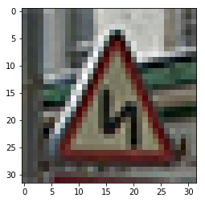

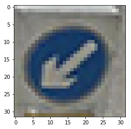

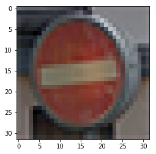

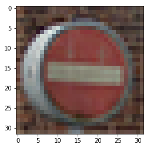

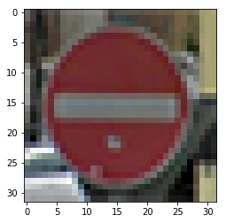

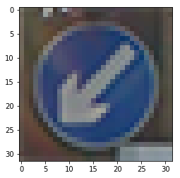

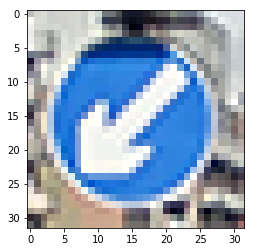

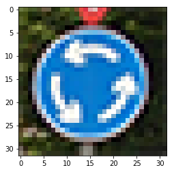

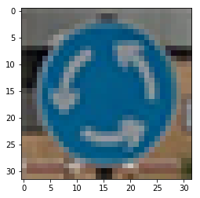

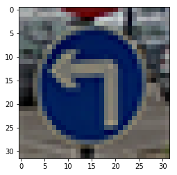

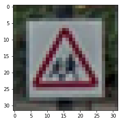

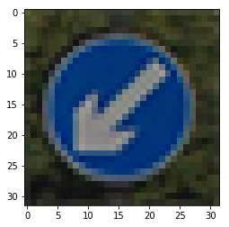

[31 more figures not shown]

```python
### Load the images and plot them here.
### Feel free to use as many code cells as needed.
# Importing the images, and let's take a look at what we have!

# Load images from .png files to `X_custom` NumPy array
X_custom = np.empty([0, 32, 32, 3], dtype = np.int32)
for i in range(43):
    image = io.imread(os.getcwd() + '/additional_images/' + "example_{0:0>5}".format(i + 1) + '.png')
    X_custom = np.append(X_custom, [image[:, :, :3]], axis = 0)
    pyplot.imshow(image)
    pyplot.show()

# Provide labels of the captured images:
y_custom = np.array([
    21, # "example_00001"
    39, # "example_00002"
    17, # "example_00003"
    17, # "example_00004"
    17, # "example_00005"
    39, # "example_00006"
    39, # "example_00007"
    40, # "example_00008"
    40, # "example_00009"
    34, # "example_00010"
    28, # "example_00011"
    39, # "example_00012"
    0, # "example_00013"
    17, # "example_00014"
    38, # "example_00015"
    13, # "example_00016"
    40, # "example_00017"
    13, # "example_00018"
    38, # "example_00019"
    38, # "example_00020"
    11, # "example_00021"
    0, # "example_00022"
    28, # "example_00023"
    0, # "example_00024"
    99, # "example_00025"
    99, # "example_00026"
    99, # "example_00027"
    32, # "example_00028"
    40, # "example_00029"
    28, # "example_00030"
    40, # "example_00031"
    40, # "example_00032"
    28, # "example_00033"
    24, # "example_00034"
    0, # "example_00035"
    0, # "example_00036"
    0, # "example_00037"
    0, # "example_00038"
    3, # "example_00039"
    34, # "example_00040"
    14, # "example_00041"
    25, # "example_00042"
    13 # "example_00043"
])
```

```python
# First, double-check the image shape to make sure it matches the original data's 32x32x3 size
print(X_custom.shape)
```

```
(43, 32, 32, 3)
```

```python
X_custom = preprocess(X_custom)

print('Finished preprocessing additional pictures.')

# Double-check that the image is changed to depth of 1
new_image_shape = X_custom.shape
print("Processed additional pictures shape =", new_image_shape)
```

```
Finished preprocessing additional pictures.
Processed additional pictures shape = (43, 32, 32, 1)
```

### Predict the Sign Type for Each Image

```python
### Run the predictions here and use the model to output the prediction for each image.
### Make sure to pre-process the images with the same pre-processing pipeline used earlier.
### Feel free to use as many code cells as needed.
### Run the predictions here.
### Feel free to use as many code cells as needed.
# Launch the model on the new pictures
with tf.Session() as sess:
    saver.restore(sess, './' + save_file)
    new_pics_classes = sess.run(logits, feed_dict={x: X_custom, keep_prob : 1.0})
```